# GAM 應用於使用電量的預測

接下來我們來看看一周的用電狀況

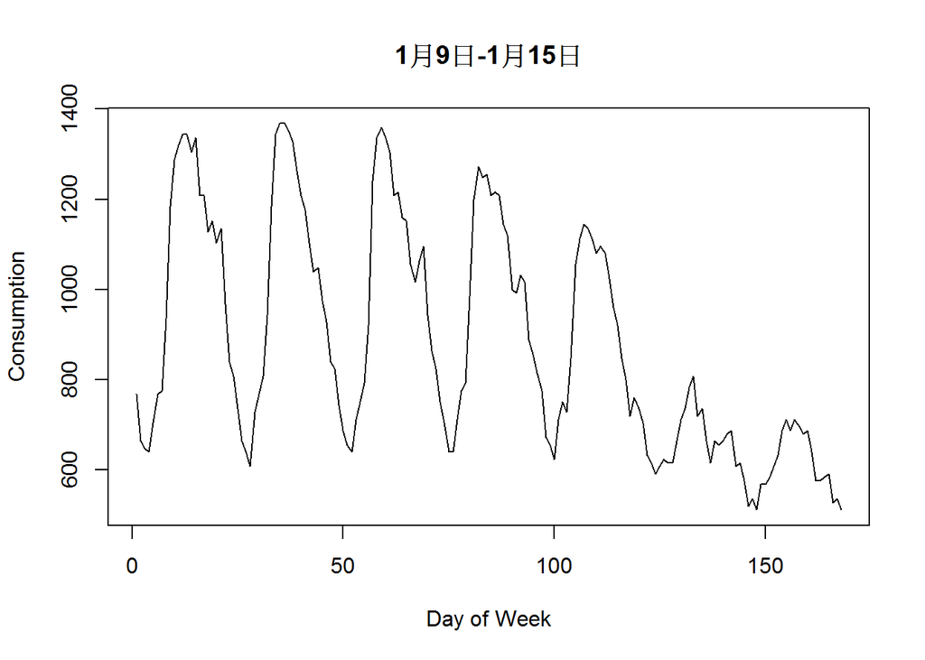

```r
plot(Consumption.data$Consumption[193:360], type = 'l', xlab = "Day of Week", ylab = "Consumption", main = "1月9日-1月15日")
```

## 接著看看一年的用電狀況

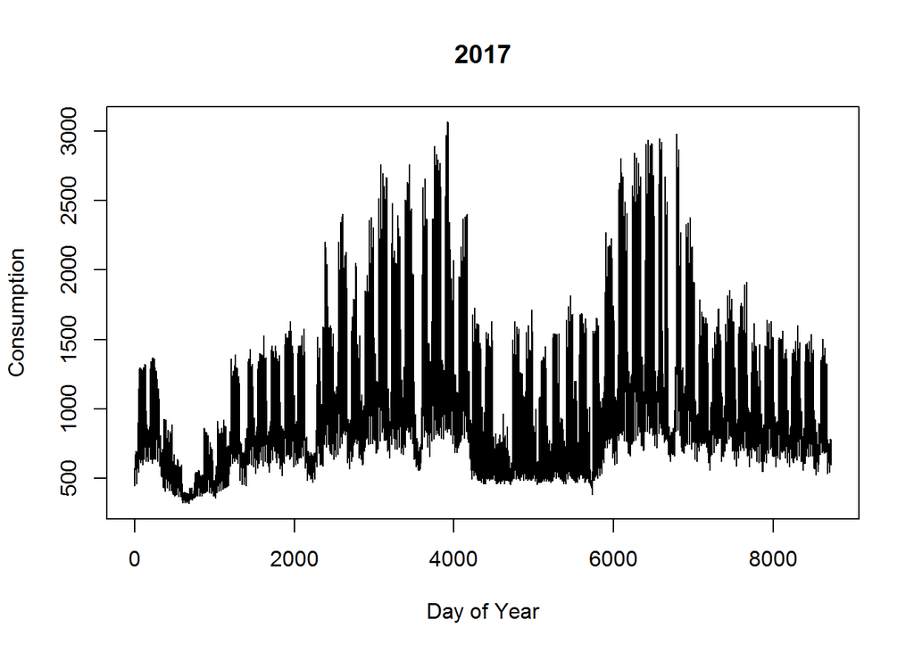

```r
plot(Consumption.data$Consumption, type = 'l', xlab = "Day of Year", ylab = "Consumption", main = "2017")
```

## 開始使用 GAM 套件對這一整年的電耗資料進行分析。

在使用GAM前要安裝“mgcv”這個package **mgcv: Mixed GAM Computation Vehicle with Automatic Smoothness Estimation**

在引入後就能用gam這個函式來做塑模

為了在資料解讀上更易讀，我們會先把DayOfWeek轉成factor

相關變數： 1. 響應變數：電耗 Comsumption 2. 日中之時：HourOfDay，接頭接尾 3. 年中之日：DayOfYear，接頭接尾 4. 週中之日：DayOfWeek (Factor)

```r
# install.packages("mgcv")
library(mgcv)
Consumption.data$DayOfWeek = factor(Consumption.data$DayOfWeek, labels = c("Mon","Tue","Wed","Thu","Fri","Sat","Sun"))
modgam = gam(formula = Consumption ~ s(HourOfDay, bs='cc') + s(DayOfYear, bs = 'cc') + DayOfWeek, family = gaussian(link = identity), data = Consumption.data)
summary(modgam)
```

```
##
## Family: gaussian
## Link function: identity
##
## Formula:
## Consumption ~ s(HourOfDay, bs = "cc") + s(DayOfYear, bs = "cc") +
##     DayOfWeek
##
## Parametric coefficients:
##              Estimate Std. Error t value Pr(>|t|)
## (Intercept)  1082.563      8.195 132.107  < 2e-16 ***
## DayOfWeekTue   41.428     11.580   3.578 0.000349 ***
## DayOfWeekWed   66.293     11.580   5.725 1.07e-08 ***
## DayOfWeekThu   66.928     11.580   5.780 7.73e-09 ***
## DayOfWeekFri  -53.799     11.589  -4.642 3.50e-06 ***
## DayOfWeekSat -310.706     11.610 -26.762  < 2e-16 ***
## DayOfWeekSun -324.272     11.556 -28.061  < 2e-16 ***
## ---
## Signif. codes:  0 '***' 0.001 '**' 0.01 '*' 0.05 '.' 0.1 ' ' 1
##
## Approximate significance of smooth terms:
##                edf Ref.df     F p-value
## s(HourOfDay) 7.788      8 970.1  <2e-16 ***
## s(DayOfYear) 7.990      8 794.7  <2e-16 ***
## ---
## Signif. codes:  0 '***' 0.001 '**' 0.01 '*' 0.05 '.' 0.1 ' ' 1
##
## R-sq.(adj) =  0.658   Deviance explained = 65.9%
## GCV =  83753  Scale est. = 83534     n = 8726
```

## 畫出塑模後預測一天的結果與實際值比較

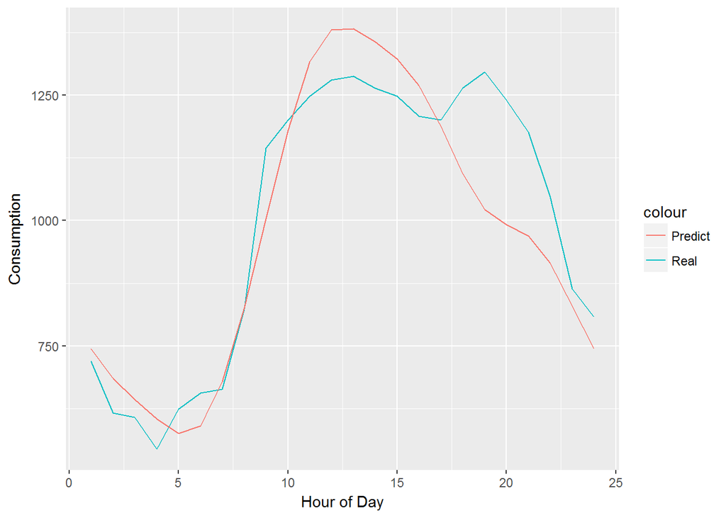

```r
library(ggplot2)
Consumption.data$Predict = modgam$fitted.values
ggplot(Consumption.data[49:72,], aes(1:24)) + labs(x = "Hour of Day") +
    geom_line(aes(y = Consumption, color = "Real")) +
    geom_line(aes(y = Predict, color = "Predict"))
```

塑模結果確實與我們預想一樣，在中午前電耗遞增，中午後遞減

## 接著是一週的預測結果

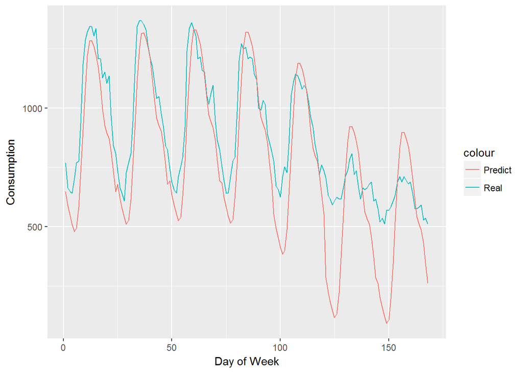

```r
ggplot(Consumption.data[193:360,], aes(1:168)) + labs(x = "Day of Week") +
    geom_line(aes(y = Consumption, color = "Real")) +
    geom_line(aes(y = Predict, color = "Predict"))
```

在星期一到星期五預測的結果都比較高，六、日則較低

## 接著看整年的預測結果

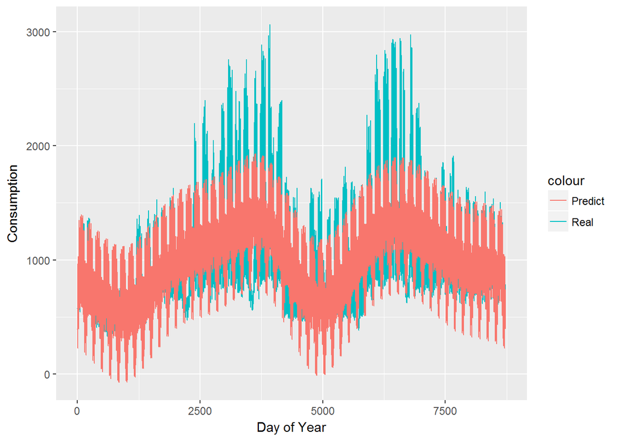

```r
ggplot(Consumption.data, aes(1:8726)) +  labs(x = "Day of Year") +
    geom_line(aes(y = Consumption, color = "Real")) +
    geom_line(aes(y = Predict, color = "Predict"))
```

在寒暑假電耗較低，並且越接近夏天電耗越高，越接近冬天電耗越低

## 之前 linear regression 時，相對應的 $\beta_i$ 為一個數字，但現在 s(HourOfDay) 以及 s(DayOfYear) 為 smooth function，要如何表達呢？

```r
modgam$coefficients
```

```
##    (Intercept)   DayOfWeekTue   DayOfWeekWed   DayOfWeekThu   DayOfWeekFri
##     1082.56347       41.42761       66.29291       66.92769      -53.79867
##   DayOfWeekSat   DayOfWeekSun s(HourOfDay).1 s(HourOfDay).2 s(HourOfDay).3
##     -310.70634     -324.27159     -298.92710     -323.77215       22.32649
## s(HourOfDay).4 s(HourOfDay).5 s(HourOfDay).6 s(HourOfDay).7 s(HourOfDay).8
##      416.40277      441.80827      323.91894      107.07742       29.93061
## s(DayOfYear).1 s(DayOfYear).2 s(DayOfYear).3 s(DayOfYear).4 s(DayOfYear).5
##     -404.11280       41.22871      231.78004      349.70787     -338.68679
## s(DayOfYear).6 s(DayOfYear).7 s(DayOfYear).8
##      147.48374      351.10102       37.10142
```

## 注意其中 DayOfWeek 的變化

```r
modgam$coefficients[1:7]
```

```
##  (Intercept) DayOfWeekTue DayOfWeekWed DayOfWeekThu DayOfWeekFri
##   1082.56347     41.42761     66.29291     66.92769    -53.79867
## DayOfWeekSat DayOfWeekSun
##   -310.70634   -324.27159
```

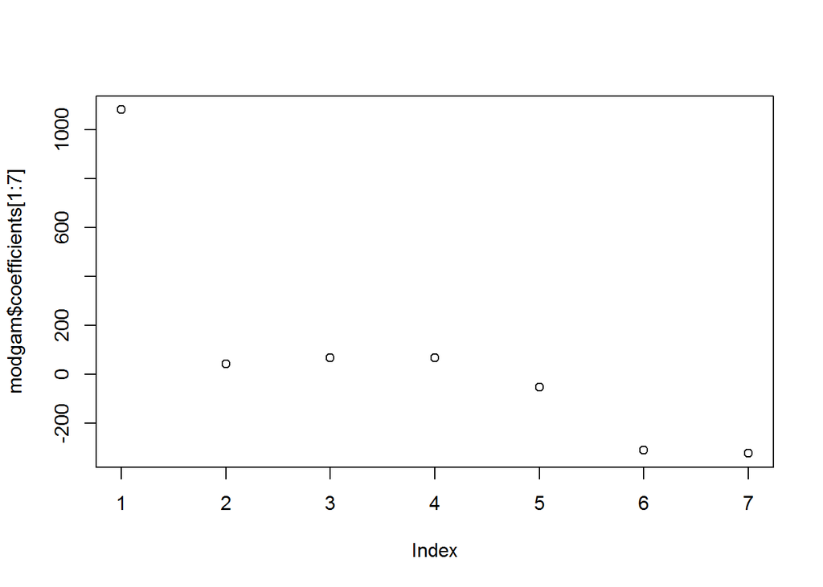

```r
plot(modgam$coefficients[1:7])
```

##其中第一項並非對應星期一的，而是所有的 baseline 的因素加入之後的平均電耗值。即為 1082。

## 更方便讀 s(HourOfDay) 以及 s(DayOfYear) 的方法是畫出來：

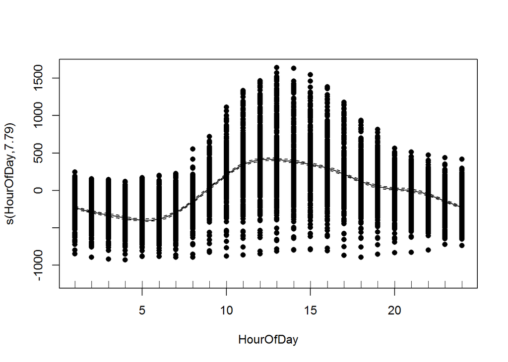

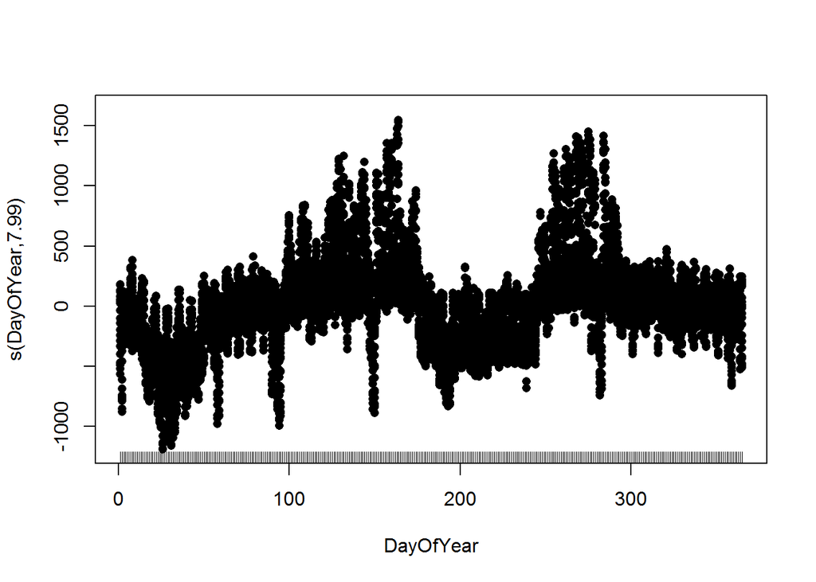

```r
plot(modgam, residuals = T,pch = 16)
```

## 接下來看看個項因素在解釋響應變數上的貢獻

逐一拿掉一項來看看：

```r
modgam2 <- update(modgam, ~. - s(HourOfDay, bs='cc') )
modgam3 <- update(modgam, ~. - s(DayOfYear, bs='cc') )
modgam4 <- update(modgam, ~. - DayOfWeek )
```

## 以下是不考量 HourOfDay 的因素

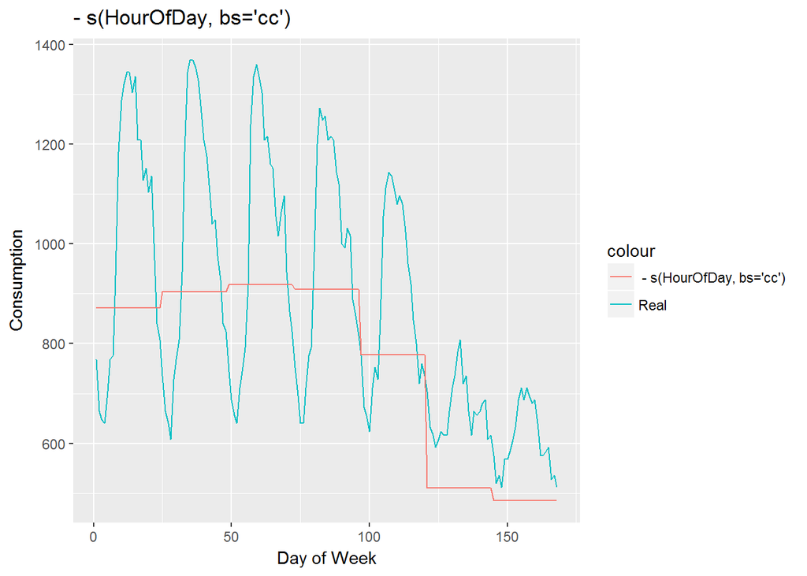

```r
Consumption.data$Predict2 = modgam2$fitted.values
ggplot(Consumption.data[193:360,], aes(1:168)) + labs(x = "Day of Week", title = "- s(HourOfDay, bs='cc') ") +
    geom_line(aes(y = Consumption, color = "Real")) +
    geom_line(aes(y = Predict2, color = " - s(HourOfDay, bs='cc') "))
```

```r
anova(modgam, modgam2, test="F")
```

```
## Analysis of Deviance Table
##
## Model 1: Consumption ~ s(HourOfDay, bs = "cc") + s(DayOfYear, bs = "cc") +
##     DayOfWeek
## Model 2: Consumption ~ s(DayOfYear, bs = "cc") + DayOfWeek
##   Resid. Df Resid. Dev      Df   Deviance      F    Pr(>F)
## 1      8703  727014180
## 2      8711 1375910302 -7.9867 -648896122 972.62 < 2.2e-16 ***
## ---
## Signif. codes:  0 '***' 0.001 '**' 0.01 '*' 0.05 '.' 0.1 ' ' 1
```

```r
648896122/7.9867
```

```
## [1] 81247089
```

```r
1375910302/727014180
```

```
## [1] 1.892549
```

## 以下是不考量 DayOfYear 的因素

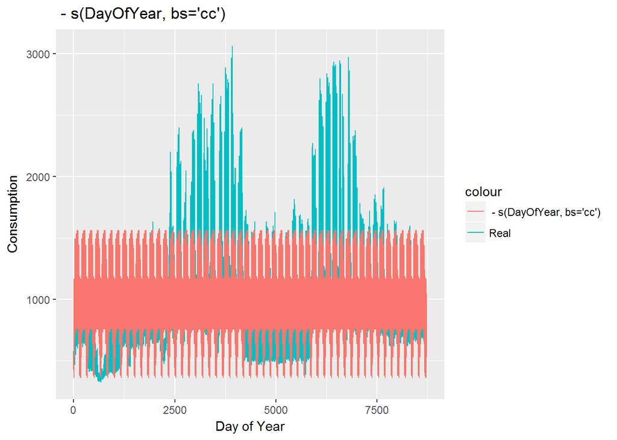

```r
Consumption.data$Predict3 = modgam3$fitted.values
ggplot(Consumption.data, aes(1:8726)) + labs(x = "Day of Year", title = " - s(DayOfYear, bs='cc') ") +
    geom_line(aes(y = Consumption, color = "Real")) +
    geom_line(aes(y = Predict3, color = " - s(DayOfYear, bs='cc') "))
```

```r
anova(modgam, modgam3, test="F")
```

```
## Analysis of Deviance Table
##
## Model 1: Consumption ~ s(HourOfDay, bs = "cc") + s(DayOfYear, bs = "cc") +
##     DayOfWeek
## Model 2: Consumption ~ s(HourOfDay, bs = "cc") + DayOfWeek
##   Resid. Df Resid. Dev      Df   Deviance      F    Pr(>F)
## 1      8703  727014180
## 2      8711 1258471734 -8.0273 -531457554 792.56 < 2.2e-16 ***
## ---
## Signif. codes:  0 '***' 0.001 '**' 0.01 '*' 0.05 '.' 0.1 ' ' 1
```

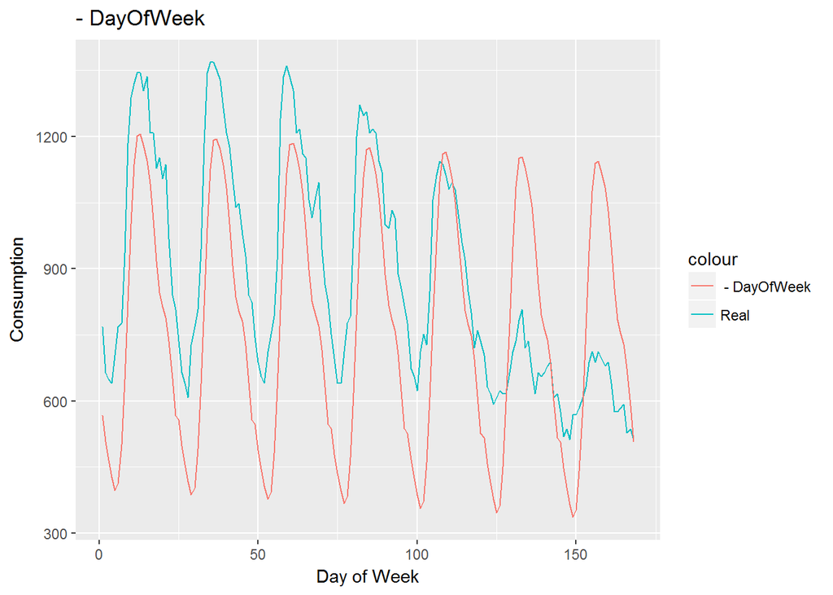

```r
Consumption.data$Predict4 = modgam4$fitted.values
ggplot(Consumption.data[193:360,], aes(1:168)) + labs(x = "Day of Week", title = "- DayOfWeek") +
    geom_line(aes(y = Consumption, color = "Real")) +
    geom_line(aes(y = Predict4, color = " - DayOfWeek "))
```

```r
anova(modgam, modgam4, test="F")
```

```
## Analysis of Deviance Table
##
## Model 1: Consumption ~ s(HourOfDay, bs = "cc") + s(DayOfYear, bs = "cc") +
##     DayOfWeek
## Model 2: Consumption ~ s(HourOfDay, bs = "cc") + s(DayOfYear, bs = "cc")
##   Resid. Df Resid. Dev      Df   Deviance      F    Pr(>F)
## 1      8703  727014180
## 2      8709  948315443 -6.0099 -221301263 440.81 < 2.2e-16 ***
## ---
## Signif. codes:  0 '***' 0.001 '**' 0.01 '*' 0.05 '.' 0.1 ' ' 1
```

## 以下是將 HourOfDay 硬看成是「線性關係」時，也就是只用一個 $\beta$ 來代表其貢獻

```r
modgam5 = gam(formula = Consumption ~ HourOfDay + s(DayOfYear, bs = 'cc') + DayOfWeek, family = gaussian(link = identity), data = Consumption.data)
summary(modgam5)
```

```
##
## Family: gaussian
## Link function: identity
##
## Formula:
## Consumption ~ HourOfDay + s(DayOfYear, bs = "cc") + DayOfWeek
##
## Parametric coefficients:
##               Estimate Std. Error t value Pr(>|t|)
## (Intercept)   875.6311    13.0585  67.054  < 2e-16 ***
## HourOfDay      16.5146     0.5887  28.054  < 2e-16 ***
## DayOfWeekTue   42.2852    15.2496   2.773 0.005568 **
## DayOfWeekWed   67.1505    15.2496   4.403 1.08e-05 ***
## DayOfWeekThu   67.7853    15.2496   4.445 8.90e-06 ***
## DayOfWeekFri  -52.8825    15.2619  -3.465 0.000533 ***
## DayOfWeekSat -309.8722    15.2899 -20.266  < 2e-16 ***
## DayOfWeekSun -324.9489    15.2186 -21.352  < 2e-16 ***
## ---
## Signif. codes:  0 '***' 0.001 '**' 0.01 '*' 0.05 '.' 0.1 ' ' 1
##
## Approximate significance of smooth terms:
##                edf Ref.df     F p-value
## s(DayOfYear) 7.982      8 458.2  <2e-16 ***
## ---
## Signif. codes:  0 '***' 0.001 '**' 0.01 '*' 0.05 '.' 0.1 ' ' 1
##
## R-sq.(adj) =  0.407   Deviance explained = 40.8%
## GCV = 1.4514e+05  Scale est. = 1.4488e+05  n = 8726
```

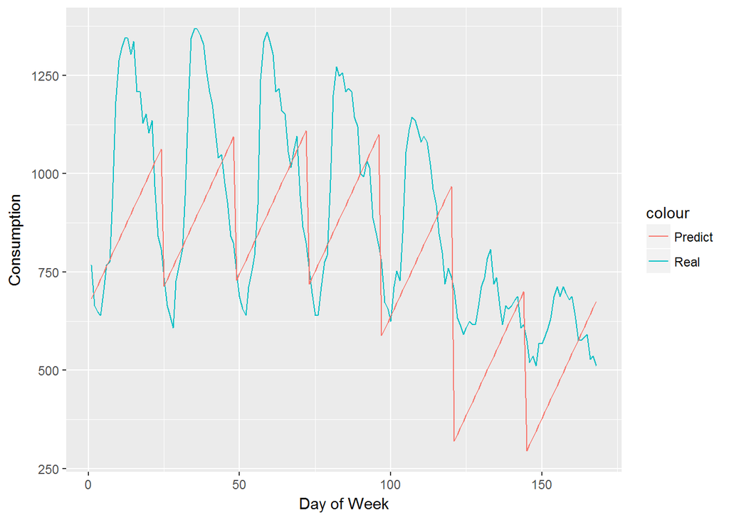

```r
Consumption.data$Predict5 = modgam5$fitted.values
ggplot(Consumption.data[193:360,], aes(1:168)) + labs(x = "Day of Week") +
    geom_line(aes(y = Consumption, color = "Real")) +
    geom_line(aes(y = Predict5, color = "Predict"))
```

## 以下是用來對比用線性以及用 smooth function 的差別

```r
anova(modgam, modgam5, test="F")
```

```
## Analysis of Deviance Table
##
## Model 1: Consumption ~ s(HourOfDay, bs = "cc") + s(DayOfYear, bs = "cc") +
##     DayOfWeek
## Model 2: Consumption ~ HourOfDay + s(DayOfYear, bs = "cc") + DayOfWeek
##   Resid. Df Resid. Dev      Df   Deviance      F    Pr(>F)
## 1      8703  727014180
## 2      8710 1261887659 -6.9867 -534873479 916.47 < 2.2e-16 ***
## ---
## Signif. codes:  0 '***' 0.001 '**' 0.01 '*' 0.05 '.' 0.1 ' ' 1
```

# 預測

我們用一個假的資料來看看預測結果，比較凌晨、中午，星期幾，四季的預測結果

```r
test.data = data.frame(
  HourOfDay = c(1, 1, 1, 1, 12, 12, 12, 12, 1, 1, 1, 1, 12, 12, 12, 12), DayOfYear = c(45, 135, 225, 315), DayOfWeek = factor(c(3,3,3,3,3,3,3,3,6,6,6,6,6,6,6,6), labels = c("Wed", "Sat"))
)
test.data
```

```
##    HourOfDay DayOfYear DayOfWeek
## 1          1        45       Wed
## 2          1       135       Wed
## 3          1       225       Wed
## 4          1       315       Wed
## 5         12        45       Wed
## 6         12       135       Wed
## 7         12       225       Wed
## 8         12       315       Wed
## 9          1        45       Sat
## 10         1       135       Sat
## 11         1       225       Sat
## 12         1       315       Sat
## 13        12        45       Sat
## 14        12       135       Sat
## 15        12       225       Sat
## 16        12       315       Sat
```

```r
test.data$predict_response = predict(object = modgam, test.data, type = "response")
test.data$predict_link = predict(object = modgam, test.data, type = "link")
test.data
```

```
##    HourOfDay DayOfYear DayOfWeek predict_response predict_link
## 1          1        45       Wed         496.8456     496.8456
## 2          1       135       Wed        1212.5890    1212.5890
## 3          1       225       Wed         716.4698     716.4698
## 4          1       315       Wed         992.6354     992.6354
## 5         12        45       Wed        1132.3677    1132.3677
## 6         12       135       Wed        1848.1110    1848.1110
## 7         12       225       Wed        1351.9919    1351.9919
## 8         12       315       Wed        1628.1574    1628.1574
## 9          1        45       Sat         119.8464     119.8464
## 10         1       135       Sat         835.5897     835.5897
## 11         1       225       Sat         339.4706     339.4706
## 12         1       315       Sat         615.6361     615.6361
## 13        12        45       Sat         755.3684     755.3684
## 14        12       135       Sat        1471.1117    1471.1117
## 15        12       225       Sat         974.9926     974.9926
## 16        12       315       Sat        1251.1581    1251.1581
```

上面的結果可以蠻明顯的看出白天的電耗都比凌晨高很多，並且星期三的電耗也比星期六來的高。

接著我們來比較四季，在冬天電耗最低，且DayOfYear是45時大約是放寒假的時候，所以電耗也會特別低。在春天(DayOfYear=135)時電耗是最高的，因為越來越接近夏天，大家都會開冷氣，而夏天電耗反而比春、秋天低，因為暑假時校園沒人，所以才會有這個情形，最後秋天的電耗是次高的。

```r
modgam6 = gam(formula = Consumption ~ s(HourOfDay, bs='cc', by = DayOfWeek) + s(DayOfYear, bs = 'cc'), family = gaussian(link = identity), data = Consumption.data)
summary(modgam6)
```

```
##
## Family: gaussian
## Link function: identity
##
## Formula:
## Consumption ~ s(HourOfDay, bs = "cc", by = DayOfWeek) + s(DayOfYear,
##     bs = "cc")
##
## Parametric coefficients:
##             Estimate Std. Error t value Pr(>|t|)
## (Intercept) 1009.048      3.312   304.7   <2e-16 ***
## ---
## Signif. codes:  0 '***' 0.001 '**' 0.01 '*' 0.05 '.' 0.1 ' ' 1
##
## Approximate significance of smooth terms:
##                             edf Ref.df      F p-value
## s(HourOfDay):DayOfWeekMon 6.790      8 187.35  <2e-16 ***
## s(HourOfDay):DayOfWeekTue 6.928      8 204.04  <2e-16 ***
## s(HourOfDay):DayOfWeekWed 6.835      8 207.83  <2e-16 ***
## s(HourOfDay):DayOfWeekThu 6.963      8 217.67  <2e-16 ***
## s(HourOfDay):DayOfWeekFri 6.629      8 145.84  <2e-16 ***
## s(HourOfDay):DayOfWeekSat 4.813      8  18.11  <2e-16 ***
## s(HourOfDay):DayOfWeekSun 5.454      8  15.29  <2e-16 ***
## s(DayOfYear)              7.988      8 696.94  <2e-16 ***
## ---
## Signif. codes:  0 '***' 0.001 '**' 0.01 '*' 0.05 '.' 0.1 ' ' 1
##
## R-sq.(adj) =  0.608   Deviance explained = 61.1%
## GCV =  96281  Scale est. = 95692     n = 8726
```

```r
anova(modgam, modgam6, test="F")
```

```
## Analysis of Deviance Table
##
## Model 1: Consumption ~ s(HourOfDay, bs = "cc") + s(DayOfYear, bs = "cc") +
##     DayOfWeek
## Model 2: Consumption ~ s(HourOfDay, bs = "cc", by = DayOfWeek) + s(DayOfYear,
##     bs = "cc")
##   Resid. Df Resid. Dev     Df   Deviance F Pr(>F)
## 1    8703.0  727014180
## 2    8666.3  829900780 36.692 -102886600
```

# 其實差不多

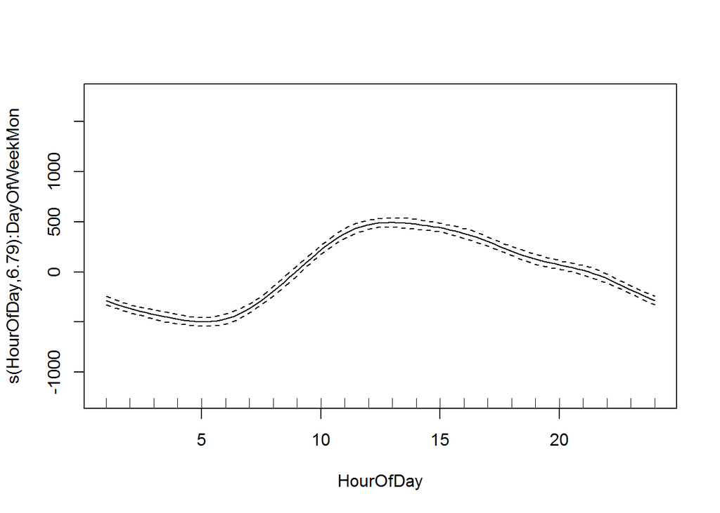

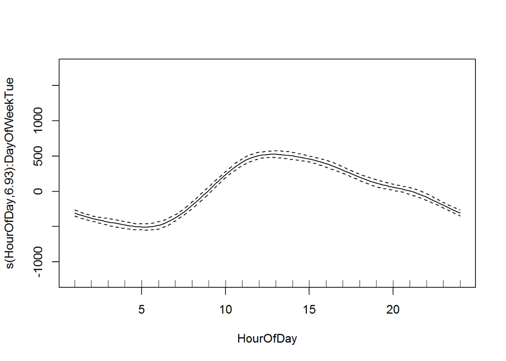

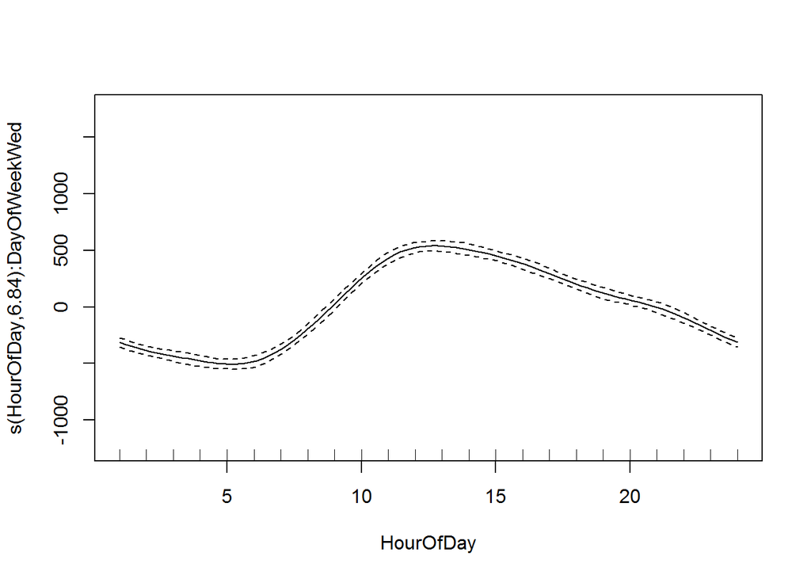

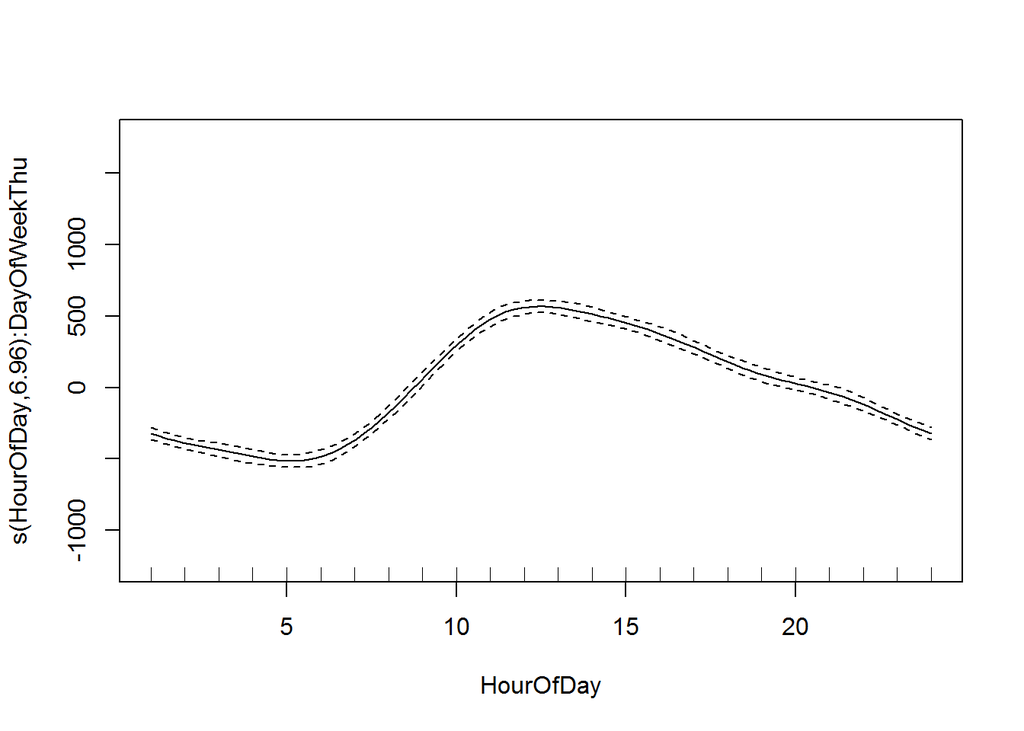

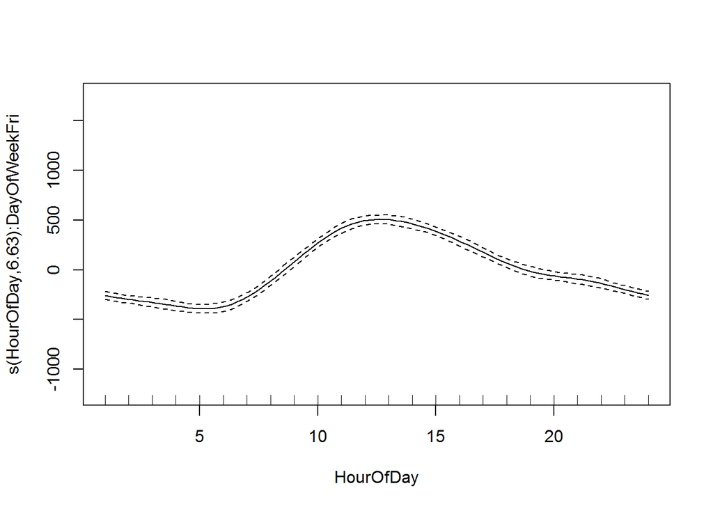

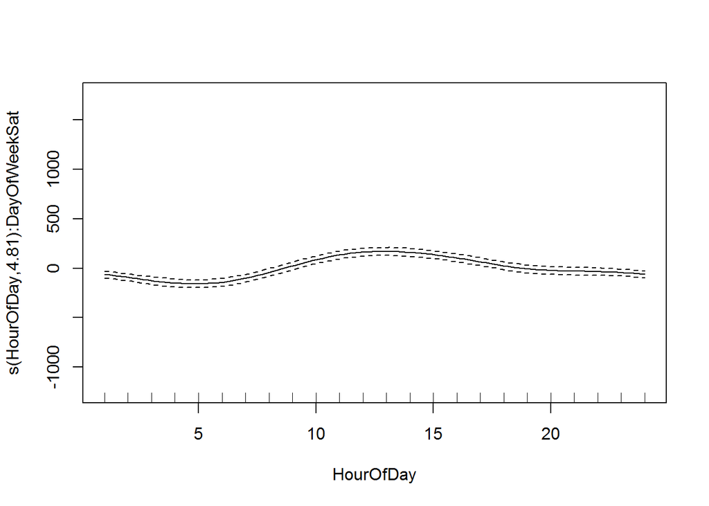

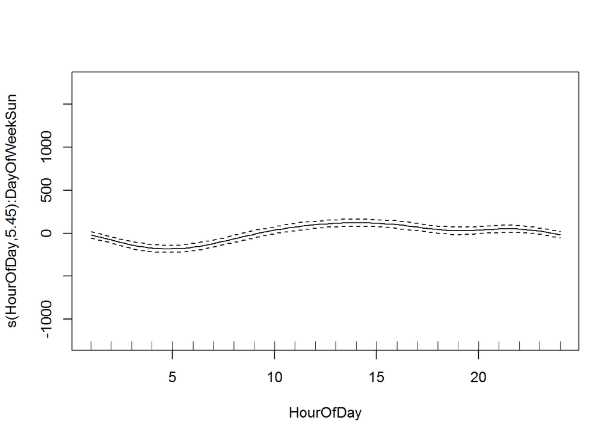

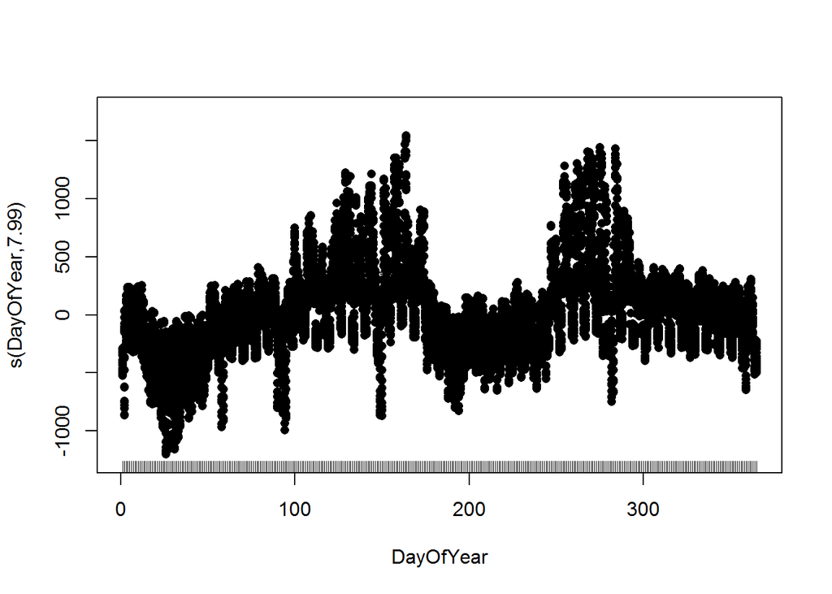

```r
plot(modgam6, residuals = T,pch = 16)
```

實在難以決定，那就問 AIC 吧！

```r
AIC(modgam)
```

```
## [1] 123679.9
```

```r
AIC(modgam6)
```

```
## [1] 124896.1
```